# Working with maps

## Why work with maps?

Over the last two years, a number of students have included “spacial analysis” as part of the professional project proposals. Examples include:

- prevalence of lead in blood samples, compared by zip codes
- examination of lead in municipal water samples
- mapping the spatial patterns of the salt through time and the geospatial resources of the greater Bonneville Salt Flats research initiative
- evaluating the effectiveness of a watershed restoration plan
- trail activity and its effects on Flammulated Owl breeding populations in Snow Basin Utah

## What are my options?

- **ggplot2 Esentials** (Chapter 7: ggplot2 and maps)
- [Making Maps with R](http://eriqande.github.io/rep-res-web/lectures/making-maps-with-R.html)
- [**ggmap : Spatial Visualization with ggplot2**](http://stat405.had.co.nz/ggmap.pdf)

## Example of a common map (USGS)

[Public Supply Water Use](https://water.usgs.gov/watuse/wups.html)

[figure not shown]

Map details can be found at https://water.usgs.gov/watuse/wups.html  
***

## Example of a common map (PSM)

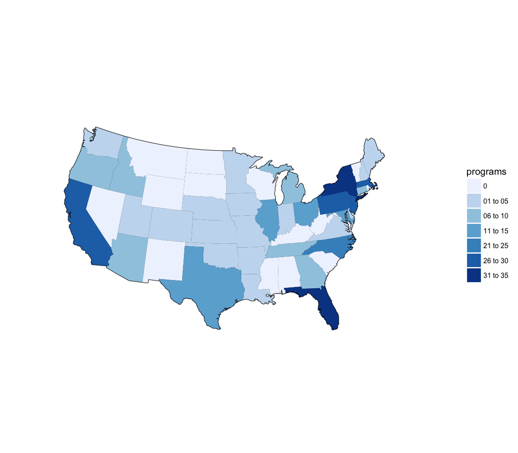

PSM programs accross the U.S.

(Created by yours truly)

## Overview of packages used for maps

We will need the flolloiwng librarys to start

```r
library(tidyverse) # this installs ggplot2 and other tidyverse pacakges
library(maps) # draw geograhpical maps
# install.packages("mapdata")
library(mapdata) # additional high resolution outlines (you may need to install the pacakge first)
```

## What is in the “maps”" pacakge

Currently available maps - world: This is a map of the entire world  
- usa: This is a map of the US coast  
- state: This is a map of the USA at the state level  
- county: This is a map of the USA at the county level  
- italy: This is a map of Italy  
- france: This is a map of France  
- nz: This is a map of New Zealand

(Excerpt From: “ggplot2 Essentials.” iBooks.)

## Let’s look at the data in “usa”

```r
head(usa)
```

```
Error in head(usa) : object 'usa' not found
```

### Format

The data file is merely a character string which specifies the name of an environment variable which contains the base location of the binary files used by the map drawing functions.

## Map of the USA

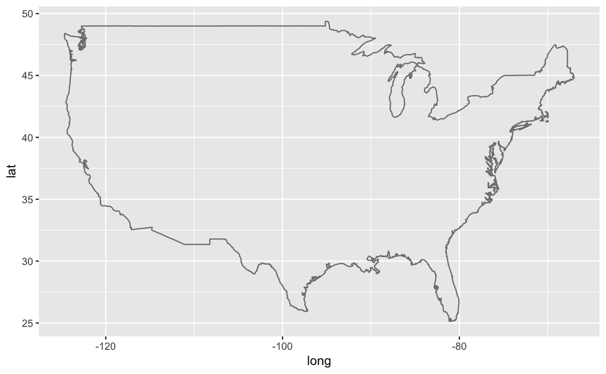

```r
ggplot() + borders(database = "usa")
```

## Let’s add some large cities to the map above

### Load the original dataset

```r
head(us.cities)
```

|  | name | country.etc | pop | lat | long | capital |
| --- | --- | --- | --- | --- | --- | --- |
| 1 | Abilene TX | TX | 113888 | 32.45 | -99.74 | 0 |
| 2 | Akron OH | OH | 206634 | 41.08 | -81.52 | 0 |
| 3 | Alameda CA | CA | 70069 | 37.77 | -122.26 | 0 |
| 4 | Albany GA | GA | 75510 | 31.58 | -84.18 | 0 |
| 5 | Albany NY | NY | 93576 | 42.67 | -73.80 | 2 |
| 6 | Albany OR | OR | 45535 | 44.62 | -123.09 | 0 |

### tidy data

```r
us_cities <- as.tibble(us.cities)
us_cities
```

| name | country.etc | pop | lat | long | capital |
| --- | --- | --- | --- | --- | --- |
| Abilene TX | TX | 113888 | 32.45 | -99.74 | 0 |
| Akron OH | OH | 206634 | 41.08 | -81.52 | 0 |
| Alameda CA | CA | 70069 | 37.77 | -122.26 | 0 |
| Albany GA | GA | 75510 | 31.58 | -84.18 | 0 |
| Albany NY | NY | 93576 | 42.67 | -73.80 | 2 |
| Albany OR | OR | 45535 | 44.62 | -123.09 | 0 |
| Albuquerque NM | NM | 494962 | 35.12 | -106.62 | 0 |
| Alexandria LA | LA | 44933 | 31.29 | -92.46 | 0 |
| Alexandria VA | VA | 127159 | 38.82 | -77.09 | 0 |
| Alhambra CA | CA | 88857 | 34.08 | -118.13 | 0 |

[output cut: 990 more lines]

## Large US cities for map

```r
large_us_cities <-  us_cities %>%
  filter(pop > 500000)
large_us_cities
```

| name | country.etc | pop | lat | long | capital |
| --- | --- | --- | --- | --- | --- |
| Austin TX | TX | 683404 | 30.31 | -97.75 | 2 |
| Baltimore MD | MD | 602658 | 39.30 | -76.61 | 0 |
| Boston MA | MA | 567759 | 42.34 | -71.02 | 2 |
| Charlotte NC | NC | 607111 | 35.20 | -80.83 | 0 |
| Chicago IL | IL | 2830144 | 41.84 | -87.68 | 0 |
| Columbus OH | OH | 741677 | 39.99 | -82.99 | 2 |
| Dallas TX | TX | 1216543 | 32.79 | -96.77 | 0 |
| Denver CO | CO | 556575 | 39.77 | -104.87 | 2 |
| Detroit MI | MI | 871789 | 42.38 | -83.10 | 0 |
| El Paso TX | TX | 603545 | 31.85 | -106.44 | 0 |

[output cut: 21 more lines]

## Use ggplot to place cities on the USA map

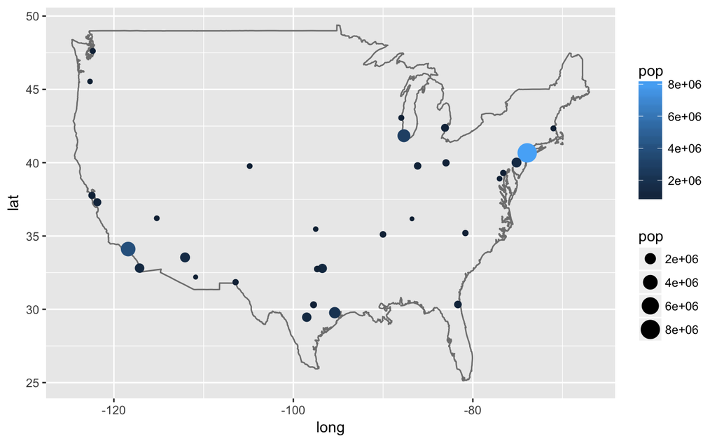

```r
ggplot() +
  borders(database = "usa") +
  geom_point(aes(long, lat, size = pop, colour = pop), large_us_cities)
```

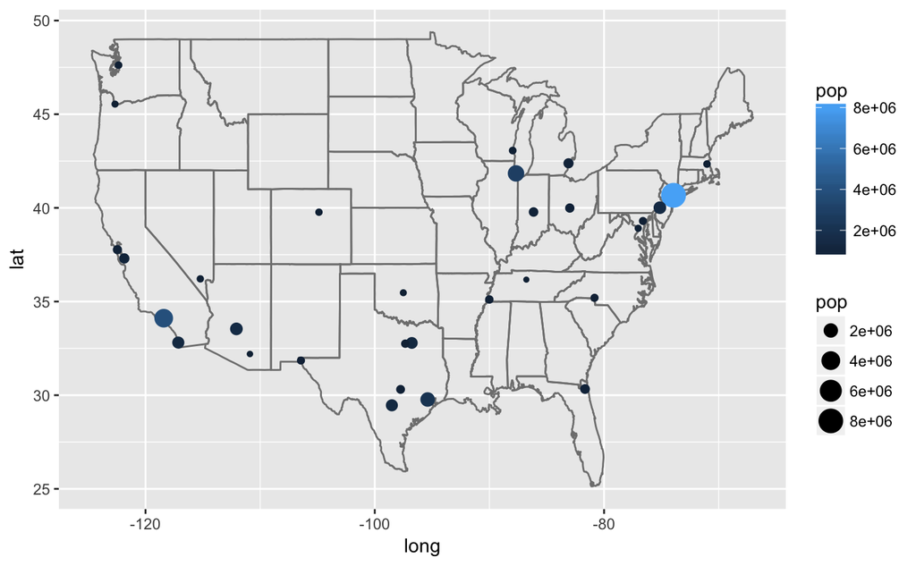

```r
ggplot() +
  borders(database = "state") +
  geom_point(aes(long, lat, size = pop, colour = pop), large_us_cities)
```

## One more item you may need

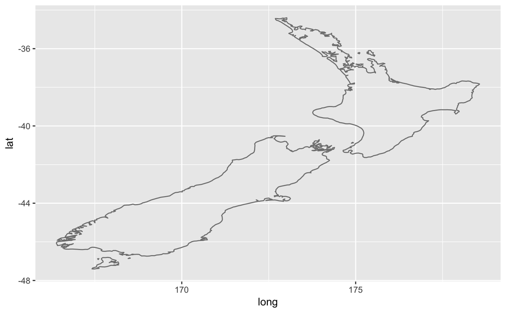

```r
ggplot() +
  borders(database = "nz")
```

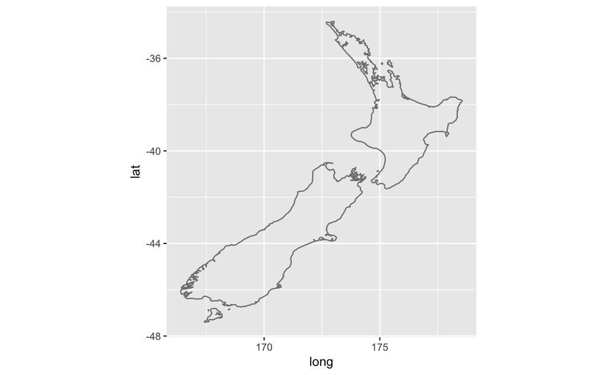

```r
ggplot() +
  borders(database = "nz") +
  coord_fixed()
```

## Life is good… unless I want to add more data to map file!

If we want to look at the map data, we need to pull it into a data frame. Using the `map_data()` function will pull this into a tibble.

```r
df_states <- map_data("state")
df_states
```

|  | long | lat | group | order | region | subregion |
| --- | --- | --- | --- | --- | --- | --- |
| 1 | -87.46201 | 30.38968 | 1 | 1 | alabama | NA |
| 2 | -87.48493 | 30.37249 | 1 | 2 | alabama | NA |
| 3 | -87.52503 | 30.37249 | 1 | 3 | alabama | NA |
| 4 | -87.53076 | 30.33239 | 1 | 4 | alabama | NA |
| 5 | -87.57087 | 30.32665 | 1 | 5 | alabama | NA |
| 6 | -87.58806 | 30.32665 | 1 | 6 | alabama | NA |
| 7 | -87.59379 | 30.30947 | 1 | 7 | alabama | NA |
| 8 | -87.59379 | 30.28655 | 1 | 8 | alabama | NA |
| 9 | -87.67400 | 30.27509 | 1 | 9 | alabama | NA |
| 10 | -87.81152 | 30.25790 | 1 | 10 | alabama | NA |

[output cut: 990 more lines]

We can try to add some aesthetics using the above info…

```r
ggplot(aes(fill = region)) +
  borders(database = "state")
```

```
Error: ggplot2 doesn't know how to deal with data of class uneval
```

So we need to look at options in the `borders()` function

```r
borders(database = "world", regions = ".", fill = NA, colour = "grey50",
  xlim = NULL, ylim = NULL, ...)
```

Working with the info above

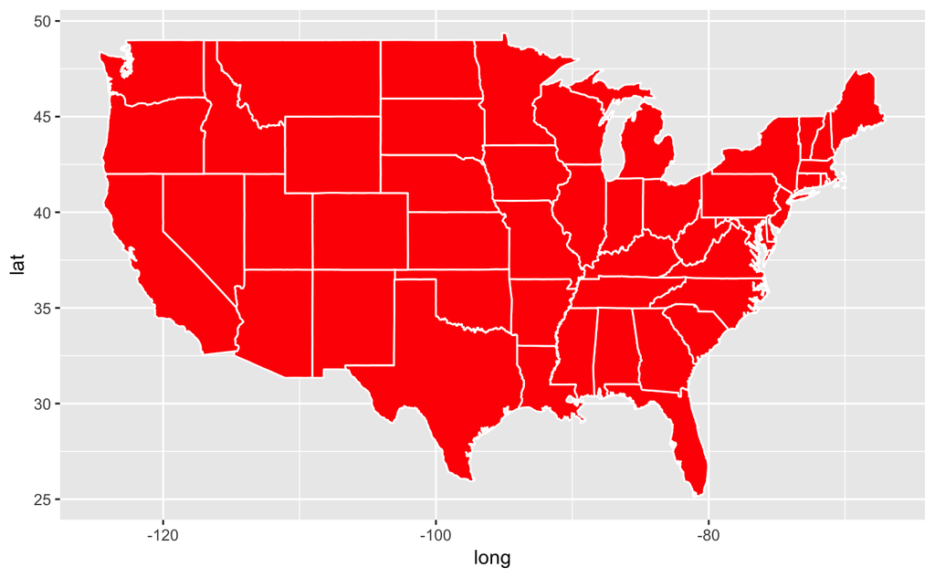

```r
ggplot() +
  borders(database = "state", fill = "red", colour = "white")
```

Or, to look at a single state (note the use of `coord_map()` which projects a portion of the spherical earth onto a flat 2D plane.

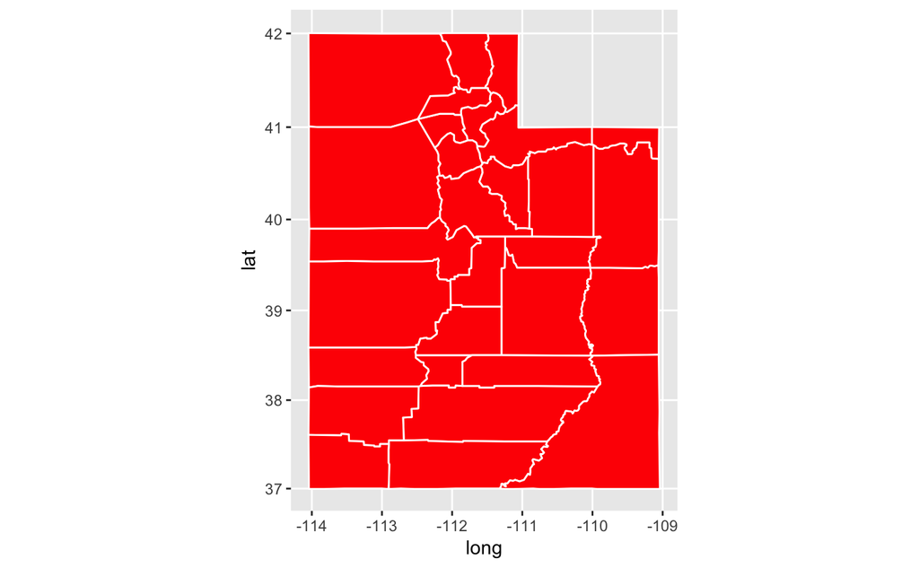

```r
ggplot() +
  borders(database = "county", regions = "Utah", fill = "red", colour = "white") +
  coord_map()
```

## What if I want to set the colour of individual state or county?

I’ll need to use the `geom_polygon()` function to represent the map

| long | lat | group | order | region | subregion |
| --- | --- | --- | --- | --- | --- |
| -79.80729 | 39.23615 | 2933 | 86738 | west virginia | barbour |
| -79.81875 | 39.14448 | 2933 | 86739 | west virginia | barbour |
| -79.81302 | 39.12156 | 2933 | 86740 | west virginia | barbour |
| -79.81302 | 39.11010 | 2933 | 86741 | west virginia | barbour |
| -79.82449 | 39.09864 | 2933 | 86742 | west virginia | barbour |
| -79.84740 | 39.09291 | 2933 | 86743 | west virginia | barbour |
| -79.87032 | 39.00124 | 2933 | 86744 | west virginia | barbour |
| -79.88750 | 38.97832 | 2933 | 86745 | west virginia | barbour |
| -79.89323 | 38.97259 | 2933 | 86746 | west virginia | barbour |
| -80.07658 | 38.94967 | 2933 | 86747 | west virginia | barbour |

[output cut: 990 more lines]

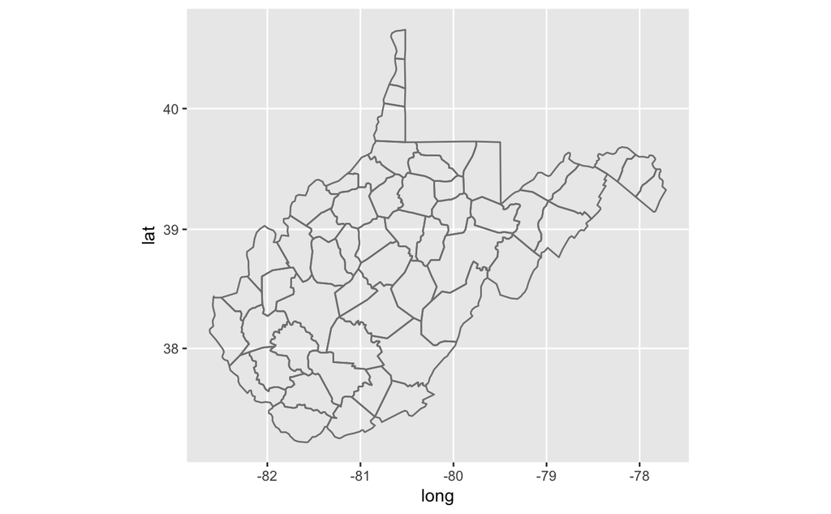

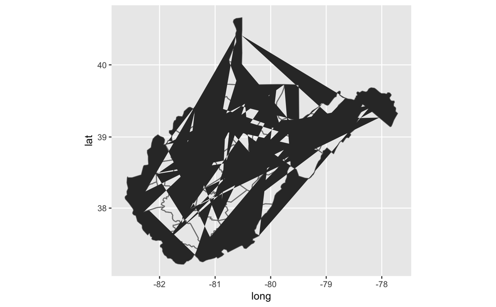

We need to indicate how to gropu the polygons

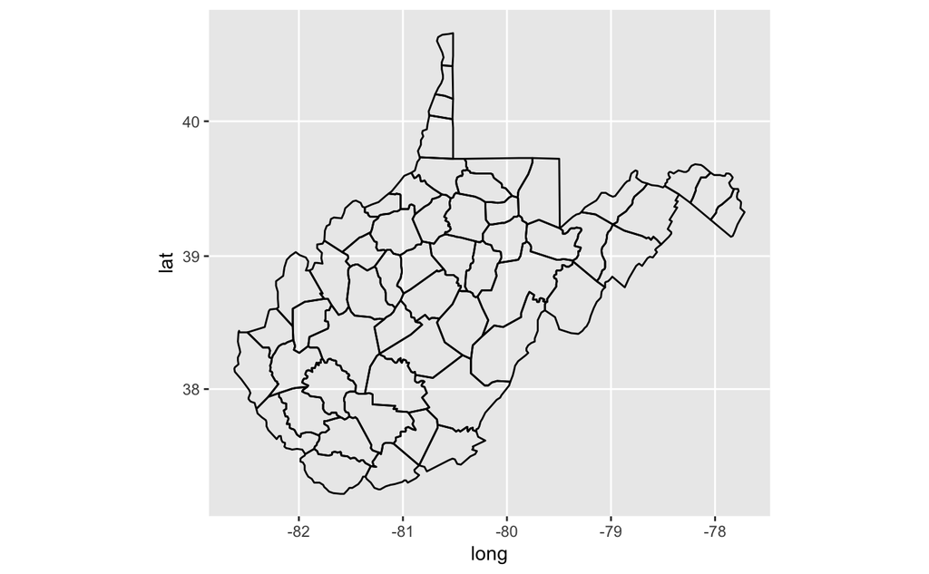

| GEO.id | GEO.id2 | GEO.display-label | respop72016 |
| --- | --- | --- | --- |
| 0500000US54001 | 54001 | Barbour County, West Virginia | 16831 |
| 0500000US54003 | 54003 | Berkeley County, West Virginia | 113525 |
| 0500000US54005 | 54005 | Boone County, West Virginia | 22816 |
| 0500000US54007 | 54007 | Braxton County, West Virginia | 14471 |
| 0500000US54009 | 54009 | Brooke County, West Virginia | 22977 |
| 0500000US54011 | 54011 | Cabell County, West Virginia | 95987 |
| 0500000US54013 | 54013 | Calhoun County, West Virginia | 7336 |
| 0500000US54015 | 54015 | Clay County, West Virginia | 8859 |
| 0500000US54017 | 54017 | Doddridge County, West Virginia | 8413 |
| 0500000US54019 | 54019 | Fayette County, West Virginia | 44323 |

[output cut: 45 more lines]

| county | pop |
| --- | --- |
| Barbour County | 16831 |
| Berkeley County | 113525 |
| Boone County | 22816 |
| Braxton County | 14471 |
| Brooke County | 22977 |
| Cabell County | 95987 |
| Calhoun County | 7336 |
| Clay County | 8859 |
| Doddridge County | 8413 |
| Fayette County | 44323 |

[output cut: 45 more lines]